# Extraction des séquences codantes (CDS) annotées sur le génome de la levure *Saccharomyces Cerevisiae*

## Enoncé du mini-projet

Le fichier S_cerevisiae_chromosomes.fna est un fichier multi-FASTA qui contient les 16 **séquences chromosomiques** de la levure *Saccharomyces cerevisiae*.

```
>BK006935.2 TPA_inf: Saccharomyces cerevisiae S288c chromosome I, complete sequence
ccacaccacacccacacacccacacaccacaccacacaccacaccacacccacacacacacatCCTAACACTACCCTAAC
ACAGCCCTAATCTAACCCTGGCCAACCTGTCTCTCAACTTACCCTCCATTACCCTGCCTCCACTCGTTACCCTGTCCCAT
TCAACCATACCACTCCGAACCACCATCCATCCCTCTACTTACTACCACTCACCCACCGTTACCCTCCAATTACCCATATC
...
```

Le fichier S_cerevisiae_annotations.gff contient les **annotations** du génome de la levure *Saccharomyces cerevisiae*.

```
##gff-version 3
#!gff-spec-version 1.20
#!processor NCBI annotwriter
#!genome-build R64-1-1
#!genome-build-accession NCBI_Assembly:GCA_000146045.2
##sequence-region BK006935.2 1 230218
##species http://www.ncbi.nlm.nih.gov/Taxonomy/Browser/wwwtax.cgi?id=559292
BK006935.2  tpg region  1   230218  .   +   .   ID=id0;Dbxref=taxon:559292;Name=I;chromosome=I;gbkey=Src;genome=chromosome;mol_type=genomic DNA;strain=S288c
BK006935.2  tpg region  1   801 .   -   .   ID=id1;Dbxref=SGD:S000028862;Note=TEL01L%3B Telomeric region on the left arm of Chromosome I%3B composed of an X element core sequence%2C X element combinatorial repeats%2C and a short terminal stretch of telomeric repeats;gbkey=telomere
BK006935.2  tpg gene    1807    2169    .   -   .   ID=gene0;Name=PAU8;gbkey=Gene;gene=PAU8;locus_tag=YAL068C
BK006935.2  tpg mRNA    1807    2169    .   -   .   ID=rna0;Parent=gene0;gbkey=mRNA;gene=PAU8;product=seripauperin PAU8
BK006935.2  tpg exon    1807    2169    .   -   .   ID=id3;Parent=rna0;gbkey=mRNA;gene=PAU8;product=seripauperin PAU8
BK006935.2  tpg CDS 1807    2169    .   -   0   ID=cds0;Parent=rna0;Dbxref=SGD:S000002142,NCBI_GP:DAA06918.1;Name=DAA06918.1;Note=hypothetical protein%3B member of the seripauperin multigene family encoded mainly in subtelomeric regions;gbkey=CDS;gene=PAU8;product=seripauperin PAU8;protein_id=DAA06918.1
...
```

L'objectif de ce mini-projet est de créer un **fichier multi-FASTA** contenant les **séquences** des **CDS** annotées (c'est-à-dire quand la 3e colonne contient "CDS" dans le fichier d'annotations).

Vous trouverez le **nom de la séquence de référence** (1re colonne), les **positions de début** (4e colonne) et **de fin** (5e colonne), le **sens** de la séquence (7e colonne) ainsi que l'**identifiant** associé à la séquence codante (sous-partie "ID=" de la 9e colonne) dans le fichier d'annotations.

Vous pourrez ainsi récupérer la portion de séquence d'intérêt dans le fichier multi-FASTA.

**Exemple de sortie :**

```
>cds0
ATGGTCAAATTAACTTCAATCGCCGCTGGTGTCGCTGCCATCGCTGCTACTGCTTCTGCA
ACCACCACTCTAGCTCAATCTGACGAAAGAGTCAACTTGGTGGAATTGGGTGTCTACGTC
TCTGATATCAGAGCTCACTTAGCCCAATACTACATGTTCCAAGCCGCCCACCCAACTGAA
ACCTACCCAGTCGAAGTTGCTGAAGCCGTTTTCAACTACGGTGACTTCACCACCATGTTG
ACCGGTATTGCTCCAGACCAAGTGACCAGAATGATCACCGGTGTTCCATGGTACTCCAGC
AGATTAAAGCCAGCCATCTCCAGTGCTCTATCCAAGGACGGTATCTACACTATCGCAAAC
TAG
>cds1
ATGCCAATTATAGGGGTGCCGAGGTGCCTTATAAAACCCTTTTCTGTGCCTGTGACATTT
CCTTTTTCGGTCAAAAAGAATATCCGAATTTTAGATTTGGACCCTCGTACAGAAGCTTAT
TGTCTAAGCCTGAATTCAGTCTGCTTTAAACGGCTTCCGCGGAGGAAATATTTCCATCTC
TTGAATTCGTACAACATTAAACGTGTGTTGGGAGTCGTATACTGTTAG
```

## Import des librairies

Voici les librairies qui peuvent vous être utiles.

```python
from Bio import SeqIO
from Bio.Seq import Seq
from Bio.SeqRecord import SeqRecord
import pandas as pd
import matplotlib.pyplot as plt
```

## Lecture du fichier multi-FASTA

La lecture du fichier multi-FASTA peut se faire de différentes manières. Au choix, vous pouvez utiliser :

1. [Biopython](https://biopython.org/)

   Utilisez l'interface SeqIO de [Biopython](https://biopython.org/) afin de convertir le fichier multi-FASTA contenant les séquences des chromosomes de *Saccharomyces cerevisiae* en dictionnaire.
2. Les fonctionnalités de base du langage Python en suivant ces deux grandes étapes :
   - Parcourez en lecture le fichier multi-FASTA,
   - Puis créez un dictionnaire (clé : nom de la séquence chromosomique , valeur : séquence chromosomique).

     Point d'attention : dans un fichier au format FASTA, la séquence est souvent répartie sur plusieurs lignes.

Dans les deux cas, la dernière ligne de la cellule de code ci-dessous affichera les clés de votre dictionnaire.

```python
# Utilisation de Biopython, j'utise les fonctions parse() et to_dict()
# de SeqIO pour produire en une ligne le dictionnaire complet des séquences
# de Saccharomyces cerivisiae

seq_dict = SeqIO.to_dict(SeqIO.parse("S_cerevisiae_chromosomes.fna", "fasta"))
print(f" Il y a bien {len(seq_dict)} chromosomes dans notre dictionnaire de séquences !")

# OPTIONNEL : Test du dictionnaire :
# for i in range(5):
#     print(seq_dict.popitem()) # permet de vérifier 5 éléments du dictionnaire
# print(f" Il n'y a plus que {len(seq_dict)} chromosomes dans notre dictionnaire de séquences !")

# /!\ Attention il faut refaire le dictionnaire après ce test, car les élements
# sont retirés par la fonction popitem() !

# Affichage des clés du dictionnaire
print(seq_dict.keys())
```

```
 Il y a bien 16 chromosomes dans notre dictionnaire de séquences !
dict_keys(['BK006935.2', 'BK006936.2', 'BK006937.2', 'BK006938.2', 'BK006939.2', 'BK006940.2', 'BK006941.2', 'BK006934.2', 'BK006942.2', 'BK006943.2', 'BK006944.2', 'BK006945.2', 'BK006946.2', 'BK006947.3', 'BK006948.2', 'BK006949.2'])
```

## Lecture du fichier GFF3

### Création du *dataframe*

Créez un *dataframe* avec la librairie [Pandas](https://python.sdv.univ-paris-diderot.fr/17_modules_interet_bioinfo/#174-module-pandas) à partir du fichier au [format GFF3](http://gmod.org/wiki/GFF3) contenant les annotations.

Les colonnes seront nommées de la manière suivante pour plus de lisibilité :

- colonne 1 : seqname
- colonne 2 : source
- colonne 3 : type
- colonne 4 : start
- colonne 5 : end
- colonne 6 : score
- colonne 7 : strand
- colonne 8 : frame
- colonne 9 : attributes

Le format GFF3 n'étant pas un fichier TSV parfait, pensez à bien lire la [documentation](https://pandas.pydata.org/pandas-docs/stable/reference/api/pandas.read_csv.html) de la fonction `.read_csv()`.

La dernière ligne de la cellule de code ci-dessous affichera les 5 premières lignes du *dataframe* créé.

```python
# J'utilise le paramètre 'comment="#"', ce qui me permet d'ignorer à la fois les 7 lignes
# du header gff3, la ligne tout à la fin, et les commentaires parcemés dans le fichier !
# Le séparateur est la tabulation, précisé avec "sep".
# Avec le paramètre "header=None", je signale qu'il n'y a pas les noms de colonnes dans le fichier.
# Je donne les noms de colonnes désirés dans une liste avec le paramètre "names".
# Dernier détail : par défaut les valeurs "start" et "end" sont inscrites comme des floats,
# je force leur enregistrement en int grâce au paramètre dtype

col_names = ["seqname", "source", "type", "start", "end", "score", "strand", "frame", "attributes"]
annotations_df = pd.read_csv("S_cerevisiae_annotations.gff", comment="#", sep="\t", header=None,
                             names=col_names, dtype={"start" : "Int64", "end" : "Int64"})

# J'affiche les 5 premières lignes du dataframe grâce à l'attribut "head"
annotations_df.head(5)
```

|  | seqname | source | type | start | end | score | strand | frame | attributes |
| --- | --- | --- | --- | --- | --- | --- | --- | --- | --- |
| 0 | BK006935.2 | tpg | region | 1 | 230218 | . | + | . | ID=id0;Dbxref=taxon:559292;Name=I;chromosome=I... |
| 1 | BK006935.2 | tpg | region | 1 | 801 | . | - | . | ID=id1;Dbxref=SGD:S000028862;Note=TEL01L%3B Te... |
| 2 | BK006935.2 | tpg | region | 707 | 776 | . | + | . | ID=id2;Dbxref=SGD:S000121252;Note=ARS102~Auton... |
| 3 | BK006935.2 | tpg | gene | 1807 | 2169 | . | - | . | ID=gene0;Name=PAU8;gbkey=Gene;gene=PAU8;locus_... |
| 4 | BK006935.2 | tpg | mRNA | 1807 | 2169 | . | - | . | ID=rna0;Parent=gene0;gbkey=mRNA;gene=PAU8;prod... |

### Filtrage du *dataframe*

Filtrez le *dataframe* afin de ne conserver que les *features* de type **CDS** et les colonnes d'intérêt suivantes :

- seqname : identifiant de la séquence de référence
- start : position de début de la séquence codante
- end : position de fin de la séquence codante
- strand : brin de la séquence codante
- attributes : informations supplémentaires dont l'identifiant (ID) de la séquence

La dernière ligne de la cellule de code ci-dessous affichera les 5 premières lignes du nouveau dataframe créé.

```python
# Je récupère seulement les lignes d'annotation dont le type est CDS
# et les stocke dans un nouveau dataframe
cds_df = annotations_df[annotations_df["type"] == "CDS"]
print(cds_df) # verification que l'on n'a plus que des CDS

# J'écrase le dataframe en ne gardant que les colonnes d'intérêt
cds_df = cds_df[["seqname", "start", "end", "strand", "attributes"]]
cds_df.head(5)
```

```
          seqname source type   start     end score strand frame  \
6      BK006935.2    tpg  CDS    1807    2169     .      -     0
10     BK006935.2    tpg  CDS    2480    2707     .      +     0
14     BK006935.2    tpg  CDS    7235    9016     .      -     0
19     BK006935.2    tpg  CDS   11565   11951     .      -     0
23     BK006935.2    tpg  CDS   12046   12426     .      +     0
...           ...    ...  ...     ...     ...   ...    ...   ...
26289  BK006949.2    tpg  CDS  939922  941136     .      +     0
26296  BK006949.2    tpg  CDS  943032  943050     .      +     0
26297  BK006949.2    tpg  CDS  943199  943896     .      +     2
26301  BK006949.2    tpg  CDS  943880  944188     .      +     0
26305  BK006949.2    tpg  CDS  944603  947701     .      +     0

                                              attributes
6      ID=cds0;Parent=rna0;Dbxref=SGD:S000002142,NCBI...
10     ID=cds1;Parent=rna1;Dbxref=SGD:S000028593,NCBI...
14     ID=cds2;Parent=rna2;Dbxref=SGD:S000000062,NCBI...
19     ID=cds3;Parent=rna3;Dbxref=SGD:S000001817,NCBI...
23     ID=cds4;Parent=rna4;Dbxref=SGD:S000002141,NCBI...
...                                                  ...
26289  ID=cds5889;Parent=rna6273;Dbxref=SGD:S00000640...
26296  ID=cds5890;Parent=rna6274;Dbxref=SGD:S00000640...
26297  ID=cds5890;Parent=rna6274;Dbxref=SGD:S00000640...
26301  ID=cds5891;Parent=rna6275;Dbxref=SGD:S00000640...
26305  ID=cds5892;Parent=rna6276;Dbxref=SGD:S00000640...

[6220 rows x 9 columns]
```

|  | seqname | start | end | strand | attributes |
| --- | --- | --- | --- | --- | --- |
| 6 | BK006935.2 | 1807 | 2169 | - | ID=cds0;Parent=rna0;Dbxref=SGD:S000002142,NCBI... |
| 10 | BK006935.2 | 2480 | 2707 | + | ID=cds1;Parent=rna1;Dbxref=SGD:S000028593,NCBI... |
| 14 | BK006935.2 | 7235 | 9016 | - | ID=cds2;Parent=rna2;Dbxref=SGD:S000000062,NCBI... |
| 19 | BK006935.2 | 11565 | 11951 | - | ID=cds3;Parent=rna3;Dbxref=SGD:S000001817,NCBI... |
| 23 | BK006935.2 | 12046 | 12426 | + | ID=cds4;Parent=rna4;Dbxref=SGD:S000002141,NCBI... |

## Écriture du fichier multi-FASTA

La sortie attendue doit contenir l'ensemble des séquences codantes (CDS) du génome au **format FASTA**. Le nom du fichier de sortie sera `S_cerevisiae_cds.fasta`.

Les informations de chaque CDS présentes dans le *dataframe* vont permettre d'extraire leurs séquences à partir du dictionnaire contenant les séquences de référence.

Grâce aux positions de début et de fin du *feature* de type CDS, vous pouvez extraire sa séquence à partir du dictionnaire préalablement créé. Dans le cas où l'élement est positionné sur le brin **-**, il faudra « inverse complémenter » la séquence :

```
séquence initiale :               5'-ATGC-3'
séquence complémentaire :         3'-TACG-5'
séquence inverse complémentaire : 5'-GCAT-3'
```

Plusieurs possibilités s'offrent à vous :

1. Si vous avez utilisé [Biopython](https://biopython.org/) pour lire le fichier multi-FASTA, utilisez également l'interface SeqIO et l'objet SeqRecord de [Biopython](https://biopython.org/) afin d'écrire le fichier de sortie au format attendu. La fonction `reverse_complement()` vous sera d'une grande aide.
2. Si vous n'avez pas utilisé [Biopython](https://biopython.org/) pour lire le fichier multi-FASTA, implémentez vous-même le *reverse complement* avec les fonctionnalités de base du langage Python.

Dans les deux cas, vous aurez besoin d'itérez sur chaque ligne du *dataframe* que vous avez créé. Voici un morceau de code qui pourra vous y aider :

```
# On suppose que le dataframe qui ne contient que les CDS s'appelle cds.
for idx in cds.index:
    seq_ref = cds.loc[idx,"seqname"]
    debut = cds.loc[idx,"start"]
    fin = cds.loc[idx,"end"]
    print(seq_ref, debut, fin)
```

```python
#__________________________________________
# Je forme une liste de SeqRecords de CDS :
#__________________________________________

liste_records_cds = []
for idx in cds_df.index:
    seq_ref = cds_df.loc[idx,"seqname"]
    debut = cds_df.loc[idx,"start"]
    fin = cds_df.loc[idx,"end"]
    strand = cds_df.loc[idx, "strand"]

    # Ici, je récupère l'ID de la CDS, je sépare la chaîne de charactères dans "attributes" en une liste
    # avec les ";" puis je prends l'élément 0 de cette liste : la chaîne de caractère contenant l'ID
    # et je n'en garde qu'une slice après les trois premiers caractères "ID=".
    cds_id = cds_df.loc[idx, "attributes"].split(sep=";")[0][3:]

    ## OPTIONNEL :
    # On peut aussi de façon similaire extraire par exemple le nom de la CDS et du produit pour en faire une
    # chaîne de caractères descriptive et l'ajouter en attribut secondaire du SeqRecord. Ce n'était pas demandé,
    # mais je préfère avoir une petite description plutôt que "<unknown description>" dans mon fichier multifasta.
    cds_description = ("|" + cds_df.loc[idx, "attributes"].split(sep=";")[3][5:] +
                       "|" + cds_df.loc[idx, "attributes"].split(sep=";")[-2][8:])

    # Selon l'orientation, je récupère la séquence sur le brin direct, ou sa séquence reverse complémentaire
    if strand == "+":
        seq_cds = seq_dict[seq_ref].seq[debut:fin]

    elif strand == "-":
        seq_cds = seq_dict[seq_ref].seq[debut:fin].reverse_complement()

    # J'ajoute à ma liste le SeqRecord correspondant à la CDS en cours, avec la séquence et l'attribut id
    # et ici en bonus une petite description
    liste_records_cds.append(SeqRecord(seq_cds, id=cds_id, description=cds_description))

#____________________________
# Ecriture du fichier fasta :
#____________________________


SeqIO.write(sequences=liste_records_cds, handle="S_cerevisiae_cds.fasta", format="fasta")
```

```
6220
```

## Répartition des différents types de *features* sur le génome

Récupérez le nombre de chaque *feature* à partir de votre *dataframe*.

Créez un graphique sous forme de barre horizontale via la librairie [Matplotlib](https://matplotlib.org/3.2.1/gallery/lines_bars_and_markers/barh.html) afin de représenter le nombre des différents types de *features* annotés sur le génome.

```
type
CDS                     6220
exon                    6595
gene                    6306
long_terminal_repeat     383
mRNA                    5899
ncRNA                    101
rRNA                      25
region                   525
tRNA                     252
dtype: int64
```

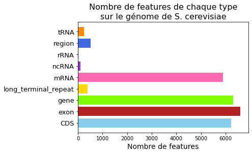

```python
# J'utilise groupby() pour obtenir l'effectif de chaque type d'annotation
print(annotations_df.groupby(["type"]).size())

## Plot :
# Pour les couleurs je me suis amusée à en choisir des nommées !
# https://matplotlib.org/stable/gallery/color/named_colors.html
color_palette = ["skyblue", "firebrick", "chartreuse", "gold", "hotpink",
                 "darkorchid", "forestgreen", "royalblue", "darkorange"]

plt.barh(annotations_df.groupby(["type"]).size().index,
         annotations_df.groupby(["type"]).size(),
         color=color_palette)

# J'ajuste les tailles des polices et ajoute des titres, dont un en 2 lignes
# pour le titre principal
plt.yticks(fontsize="13")
plt.xlabel("Nombre de features", fontsize="14")
plt.title("""Nombre de features de chaque type
sur le génome de S. cerevisiae""", fontsize="16")

# Je sauvegarde la figure au format png
plt.savefig("features_par_type.png", dpi=200, bbox_inches="tight")
```